# R Notebook

### NJ Bootstrapping with phyDat / phangorn

なんかもうひとつのboot.phylo()がうまくいってるのかわからないのでこちらを使う。NJ / UPGMAの場合、bootstrap.phyDat()を使う[source document](https://rdrr.io/cran/phangorn/man/bootstrap.pml.html)

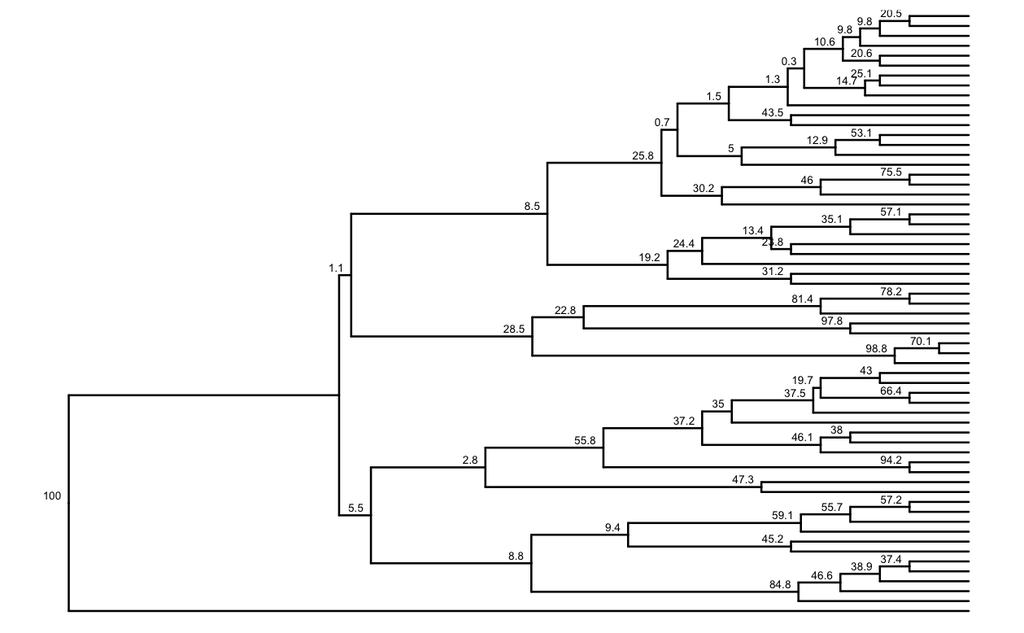

# what next?

plot (04) or ancestral character reconstruction(02).

# appendices

できるけど… SplitsTree4のものを読み込めるらしいので、それでやってみるか

plot isn’t really good and does not match exactly with SplitsTree4 output, probably because `neighborNet()` func is experimental. use SplitsTree4 using write.nexus()?

```r
sak_dist2 <- sak_phyDat |> dist.hamming() # must be phyDat
sak_nn_test <- sak_dist2 |>
  neighborNet() # takes 30sec

sak_nn_test |> as_tibble()
sak_nn_test |> write.nexus.networx(file = "data/sak_network_networx.nex")
# read and save again on st4
sak_nn_test2 <- read.nexus.networx(file = "data/sak_network_networx.nex")
sak_nn_test2 |> as_tibble() |> View() # duplicate branches? no, except for one (node 1)
sak_nn_test2 |> ggsplitnet() # can be rendered
sak_nn <- read.nexus.networx(file = "data/sak_networkFilter003_bs.nex")
sak_nn |> as_tibble() |> View() #61 tips, 237 internal nodes
sak_nn_test2 # 62 tips, 907 internal nodes

sak_nn2 <- sak_nn |>
  as_tibble() |>
  filter(branch.length > 0) |>
  as.phylo()
sak_nn2 |> View()
sak_nn2 |>
  ggsplitnet()
sak_nn2 |>
  ggsplitnet(ladderize = FALSE)
sak_nn_test |>
  ggsplitnet()
df_sak_nn <- sak_nn |>
  as_tibble() |> #View()
  left_join(df_sak_rowid, by = "node") |>
  select(parent:class, short_name, Functions, width, weight, id) |>
  rowid_to_column() |>
  mutate(short_name = if_else(is.na(short_name), rowid |> as.character(), short_name)) |>
  # column_to_rownames(var = "short_name") |>
  mutate(node = node |> as.numeric()) |>
  select(short_name, node, class, id, Functions, weight, width)
sak_nn2 <- full_join(sak_nn, df_sak_nn, by = "node")
```

[output not shown]

### plot NN

```r
sak_nn |>  ggsplitnet()
  geom_splitnet(size = .1) +
  geom_tiplab2(size = 2, family = "Fira Code", hjust = -.1) +
  theme_tree() +
  ggexpand(.1) +
  ggexpand(.1, direction=-1)
ggsave(filename = "output/sak_nn.pdf",
       device = cairo_pdf,
       dpi = 450,
       unit = "mm",
       height = 360, # pixelsでのサイズ
       width = 360,  # pixelsでのサイズ
       limitsize = FALSE)
```

networx()ではかなりできることが少ないので、SplitsTree4を使わないといけなさそう：

```r
# data(yeast, package="phangorn")
# dm <- phangorn::dist.ml(yeast)
# nnet <- phangorn::neighborNet(dm)
```

## Delta Score

デルタスコア計算できるのはいいけど、ネットワークの形がSplitsTree4と違うので参考程度にしかならないか。

```r
data(yeast)
hist(delta.score(yeast, "all"))
```

[output not shown]

```r
# compute delta score. takes 1min, sometimes it fails with error object 'decreasing' not found
# re-run it and it works (at least it worked)
sak_delta_all <- sak_phyDat |> delta.score(arg = "all")


sak_delta_all |>
  hist()
mean(sak_delta_all) # identical to delta.score()
length(sak_delta_all)
```

[output not shown]